# Practical Machine Learning - Quantified Self Analysis

Coursera Project

Yuri Danilenko

## Introduction

The project concerns the analysis and prediction of the data, collected using wearable fitness devices. Specifically, it’s required to do a quantification of how well barbell lifts excercise are done, using the data collected from accelerometers on the belt, forearm, arm, and dumbell of 6 participants, who were asked to perform excercise in 5 different ways.

We will use the data to predict the manner in which they did the exercise. Thus, the goal of this course project is to build a model to predict the classification, represented by the “classe” variable.

(The data and description is available here: http://groupware.les.inf.puc-rio.br/har)

## Preparation

```r
# Packages for analysis
library(caret)
library(randomForest)
library(corrplot)

# The random seed
set.seed(7610)
```

### Loading the Data

```r
training_data_url <-"https://d396qusza40orc.cloudfront.net/predmachlearn/pml-training.csv"
test_data_url <- "https://d396qusza40orc.cloudfront.net/predmachlearn/pml-testing.csv"
data_dir <- "./pmldataset"
training_file_name <- paste0(data_dir, "/pml-training.csv")
test_file_name  <- paste0(data_dir, "/pml-testing.csv")
# Download data 1st time only
if (!file.exists(data_dir)) {
  dir.create(data_dir)
  download.file(training_data_url, destfile=training_file_name, method="curl")
  download.file(test_data_url, destfile=test_file_name, method="curl")
}
# Load CSV data into data frames
training_dataset <- read.csv(training_file_name)
test_dataset <- read.csv(test_file_name)
```

## Exploratory Data Analysis

```r
dim(training_dataset)
```

```
## [1] 19622   160
```

```r
dim(test_dataset)
```

```
## [1]  20 160
```

The training data set size is 19622 observations and 160 variables, while the testing data set contains 20 observations and 160 variables.

## Data Cleaning

To proceed with the analysis, we have to clean up the data. We start from removing columns that contain NA values, “near zero variance” predictor values and first 7 metadata columns:

```r
training_dataset <- training_dataset[, colSums(is.na(training_dataset)) == 0]
test_dataset <- test_dataset[, colSums(is.na(test_dataset)) == 0]
# Get rid of near zero values
nearZeroTraining <- nearZeroVar(training_dataset)
training_dataset <- training_dataset[, -nearZeroTraining]
nearZeroTest <- nearZeroVar(test_dataset)
training_dataset <- training_dataset[, -nearZeroTest]
# Remove metadata columns from the training
training_dataset <- training_dataset[, -(1:7)]
dim(training_dataset)
```

```
## [1] 19622    51
```

### Partitioning Data

Let’s partition data into a real training data set and a validation data set using 70% to 30% split:

```r
inTrain <- createDataPartition(training_dataset$classe, p=0.70, list=F)
training_data <- training_dataset[inTrain, ]
validation_data <- training_dataset[-inTrain, ]
```

## Prediction With Random Forest Model

For the model we going to use the **Random Forest** approach, since it’s the most appropriate for this prediction task, assuming that multiple covariates could be correlated, with **K-fold cross validation**. After experimentation with model parameters, we decided to use 8 folds cross validation size with number of trees = 250, as good option from computation time and accuracy standpoint:

```r
model_file_name <- paste0(data_dir, "/model_random_forest")
# Cache model in file to avoide costly re-calculations
if (!file.exists(model_file_name)) {
  model_random_forest <- train(classe ~ ., data=training_data, method="rf", trControl=trainControl(method="cv", 8), ntree=250)
  saveRDS(model_random_forest, model_file_name)
} else {
  model_random_forest <- readRDS(model_file_name)
}
model_random_forest
```

```
## Random Forest
##
## 13737 samples
##    50 predictor
##     5 classes: 'A', 'B', 'C', 'D', 'E'
##
## No pre-processing
## Resampling: Cross-Validated (8 fold)
## Summary of sample sizes: 12021, 12020, 12020, 12020, 12021, 12019, ...
## Resampling results across tuning parameters:
##
##   mtry  Accuracy   Kappa      Accuracy SD  Kappa SD
##    2    0.9879162  0.9847110  0.002444167  0.003093164
##   26    0.9895176  0.9867379  0.002885791  0.003652051
##   50    0.9847858  0.9807500  0.002791504  0.003535076
##
## Accuracy was used to select the optimal model using  the largest value.
## The final value used for the model was mtry = 26.
```

Then, we estimate the performance of the model on the validation data set.

```r
prediction_validation <- predict(model_random_forest, validation_data)
cm <- confusionMatrix(validation_data$classe, prediction_validation)
cm
```

```
## Confusion Matrix and Statistics
##
##           Reference
## Prediction    A    B    C    D    E
##          A 1672    2    0    0    0
##          B   17 1119    3    0    0
##          C    0   11 1012    3    0
##          D    1    0   13  949    1
##          E    0    0    3   13 1066
##
## Overall Statistics
##
##                Accuracy : 0.9886
##                  95% CI : (0.9856, 0.9912)
##     No Information Rate : 0.2872
##     P-Value [Acc > NIR] : < 2.2e-16
##
##                   Kappa : 0.9856
##  Mcnemar's Test P-Value : NA
##
## Statistics by Class:
##
##                      Class: A Class: B Class: C Class: D Class: E
## Sensitivity            0.9893   0.9885   0.9816   0.9834   0.9991
## Specificity            0.9995   0.9958   0.9971   0.9970   0.9967
## Pos Pred Value         0.9988   0.9824   0.9864   0.9844   0.9852
## Neg Pred Value         0.9957   0.9973   0.9961   0.9967   0.9998
## Prevalence             0.2872   0.1924   0.1752   0.1640   0.1813
## Detection Rate         0.2841   0.1901   0.1720   0.1613   0.1811
## Detection Prevalence   0.2845   0.1935   0.1743   0.1638   0.1839
## Balanced Accuracy      0.9944   0.9922   0.9893   0.9902   0.9979
```

The estimated accuracy of the model is 98.9 and the estimated out-of-sample error is 1.14%.

The plot with variable importance for the recommended model could be seen in the Appendix 1.

## Predicting for Test Data Set

Now we are ready to calculate the prediction for the test data set below:

```r
prediction <- predict(model_random_forest, test_dataset[, -length(names(test_dataset))])
prediction
```

```
##  [1] B A B A A E D B A A B C B A E E A B B B
## Levels: A B C D E
```

## Appendix 1: Figures

### Correlation Matrix

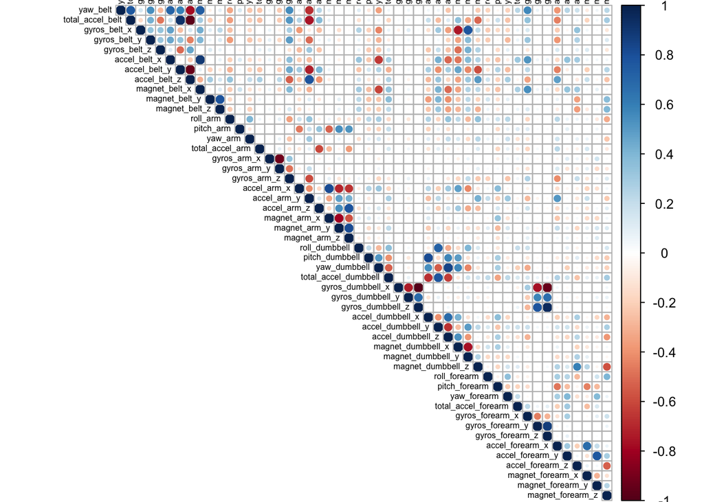

```r
corrplot(cor(training_data[, -length(names(training_data))]),
         method="circle", type = "upper", tl.col="black", tl.cex = 0.5, tl.offset=0.2, tl.pos = "td")
```

### Variable Importance Plot

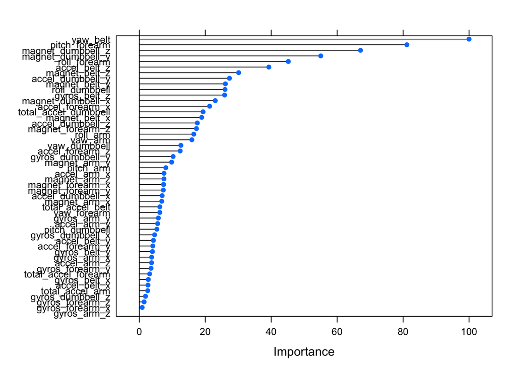

```r
plot(varImp(model_random_forest))
```

# Appendix 2: Course Project Test Cases

The files for the test submission were generated by the code below:

```r
## Convert to char vector
prediction <- as.character(prediction)
## Function that writes to single files (from the instructions)
pml_write_files = function(x){
  n = length(x)
  for(i in 1:n){
    filename = paste0("problem_id_",i,".txt")
    write.table(x[i],file=filename,quote=FALSE,row.names=FALSE,col.names=FALSE)
  }
}
## Write files
pml_write_files(prediction)
```